# Multi-Class Tabular Model for Durum Wheat Identification Using Python and TensorFlow Decision Forests

### April 26, 2022

Template Credit: Adapted from a template made available by Dr. Jason Brownlee of Machine Learning Mastery. [https://machinelearningmastery.com/]

SUMMARY: This project aims to construct a predictive model using various machine learning algorithms and document the end-to-end steps using a template. The Durum Wheat Identification dataset is a multi-class modeling situation where we attempt to predict one of several (more than two) possible outcomes.

INTRODUCTION: INTRODUCTION: Wheat is the main ingredient of most common food products in many people's daily lives. Obtaining good quality wheat kernels is an essential matter for food supplies. In this study, the research team attempted to examine and classify type-1252 durum wheat kernels to obtain top-quality crops based on their vitreousness. The researchers used a total of 236 morphological, color, wavelet, and gaborlet features to classify durum wheat kernels and foreign objects by training several Artificial Neural Networks (ANNs) with different amounts of elements based on the feature rank list obtained with the ANOVA test.

CONCLUSION: In this iteration, the TensorFlow Decision Forests model appeared to be a suitable algorithm for modeling this dataset.

Dataset Used: Durum Wheat Dataset

Dataset ML Model: Multi-Class classification with numerical features

Dataset Reference: https://www.muratkoklu.com/datasets/

One source of potential performance benchmarks: https://doi.org/10.1016/j.compag.2019.105016

## Task 1 - Prepare Environment

```python
# Install TensorFlow Decision Forests.
!pip3 install tensorflow_decision_forests --upgrade
```

```python
# Retrieve the CPU information
ncpu = !nproc
print("The number of available CPUs is:", ncpu[0])
```

```
The number of available CPUs is: 2
```

### 1.a) Load libraries and modules

```python
# Set the random seed number for reproducible results
RNG_SEED = 888
```

```python
import random
random.seed(RNG_SEED)
import numpy as np
np.random.seed(RNG_SEED)
import pandas as pd
import seaborn as sns
import matplotlib
import matplotlib.pyplot as plt
import os
import sys
import math
# import boto3
import zipfile
from datetime import datetime
from sklearn import preprocessing
from sklearn.model_selection import train_test_split
from sklearn.model_selection import RepeatedKFold
from sklearn.metrics import classification_report
from sklearn.metrics import confusion_matrix
from sklearn.metrics import accuracy_score
from sklearn.pipeline import Pipeline
from sklearn import compose
from sklearn import impute
from sklearn import metrics
import tensorflow as tf
tf.random.set_seed(RNG_SEED)
# from tensorflow import keras
import tensorflow_decision_forests as tfdf
```

```
WARNING:root:TF Parameter Server distributed training not available (this is expected for the pre-build release).
```

### 1.b) Set up the controlling parameters and functions

```python
# Begin the timer for the script processing
start_time_script = datetime.now()

# Set up the number of CPU cores available for multi-thread processing
N_JOBS = 1

# Set up the flag to stop sending progress emails (setting to True will send status emails!)
NOTIFY_STATUS = False

# Set the percentage sizes for splitting the dataset
TEST_SET_RATIO = 0.1
VAL_SET_RATIO = 0.1

# Set the number of folds for cross validation
N_FOLDS = 5
N_ITERATIONS = 1

# Set various default modeling parameters
DEFAULT_METRICS = ["accuracy", tf.keras.metrics.SparseCategoricalCrossentropy()]

# Define the directory locations and file names
TRAIN_DATASET = 'Durum_Wheat_Features.csv'

# Print out the TensorFlow version for confirmation
print('TensorFlow version:', tf.__version__)

# Check the version of TensorFlow Decision Forests
print("Found TensorFlow Decision Forests v" + tfdf.__version__)
```

```
TensorFlow version: 2.8.0
Found TensorFlow Decision Forests v0.2.4
```

```python
# Set up the email notification function
def status_notify(msg_text):
    access_key = os.environ.get('SNS_ACCESS_KEY')
    secret_key = os.environ.get('SNS_SECRET_KEY')
    aws_region = os.environ.get('SNS_AWS_REGION')
    topic_arn = os.environ.get('SNS_TOPIC_ARN')
    if (access_key is None) or (secret_key is None) or (aws_region is None):
        sys.exit("Incomplete notification setup info. Script Processing Aborted!!!")
    sns = boto3.client('sns', aws_access_key_id=access_key, aws_secret_access_key=secret_key, region_name=aws_region)
    response = sns.publish(TopicArn=topic_arn, Message=msg_text)
    if response['ResponseMetadata']['HTTPStatusCode'] != 200 :
        print('Status notification not OK with HTTP status code:', response['ResponseMetadata']['HTTPStatusCode'])
```

```python
if NOTIFY_STATUS: status_notify("Task 1 - Prepare Environment has begun! " + datetime.now().strftime('%a %B %d, %Y %I:%M:%S %p'))
```

### 1.c) Load dataset

```python
# Clean up the old files and download directories before receiving new ones
# !rm Durum_Wheat_Features.csv
```

```python
if not os.path.exists(TRAIN_DATASET):
    !wget https://dainesanalytics.com/datasets/muratkoklu-durum-wheat-dataset/Durum_Wheat_Features.csv
```

```python
df_dataset_import = pd.read_csv(TRAIN_DATASET, index_col=False)

# Take a peek at the dataframe after import
print(df_dataset_import.head())
```

```
     Target  AREA   MAJORAXIS  MINORAXIS  ECCENTRICITY     EQDIASQ  \
0  Vitreous   168  109.576157  39.396721      0.973060  213.904236
1  Vitreous   162  105.584457  43.366894      0.964173  206.264801
2  Vitreous   145   97.360207  35.532028      0.903072  184.619720
3  Vitreous   178  104.080582  49.040062      1.272657  226.636627
4  Vitreous   187  103.716667  40.885876     -1.469139  238.095779

    PERIMETER  SOLIDITY  ROUNDNESS  SHAPEFACTOR  ...  Gabor_Y9(XYZ)  \
0  202.794052  0.087454   0.017815     0.051334  ...       1.187631
1  194.794052  0.081901   0.018502     0.053650  ...       2.437782
2  177.722961  0.096026   0.019477     0.057689  ...       0.527286
3  202.509750  0.080507   0.020921     0.054543  ...       2.277434
4  198.811233  0.097650   0.022134     0.059452  ...       2.337524

   Gabor_Z1(XYZ)  Gabor_Z2(XYZ)  Gabor_Z3(XYZ)  Gabor_Z4(XYZ)  Gabor_Z5(XYZ)  \
0       0.003489       0.013901       0.031153       0.003591       0.014329
1       0.003794       0.015126       0.033886       0.004166       0.016921
2       0.003069       0.012269       0.027538       0.003092       0.012459
3       0.003743       0.014940       0.033508       0.003966       0.015513
4       0.003599       0.014423       0.032525       0.003922       0.015026

   Gabor_Z6(XYZ)  Gabor_Z7(XYZ)  Gabor_Z8(XYZ)  Gabor_Z9(XYZ)
0       0.032405       0.235286       0.651593       0.775182
1       0.038586       0.368535       1.074773       1.577847
2       0.028380       0.111476       0.191517       0.350966
3       0.034776       0.180135       0.887808       1.446794
4       0.034003       0.199192       0.928664       1.786701

[5 rows x 237 columns]
```

```python
df_dataset_import.info(verbose=True)
```

```
<class 'pandas.core.frame.DataFrame'>
RangeIndex: 9000 entries, 0 to 8999
Data columns (total 237 columns):
 #    Column           Dtype
---   ------           -----
 0    Target           object
 1    AREA             int64
 2    MAJORAXIS        float64
 3    MINORAXIS        float64
 4    ECCENTRICITY     float64
 5    EQDIASQ          float64
 6    PERIMETER        float64
 7    SOLIDITY         float64
 8    ROUNDNESS        float64
 9    SHAPEFACTOR      float64
```

[output cut: 229 more lines]

```python
print(df_dataset_import.describe())
```

```
              AREA    MAJORAXIS    MINORAXIS  ECCENTRICITY      EQDIASQ  \
count  9000.000000  9000.000000  9000.000000   9000.000000  9000.000000
mean    161.262333    94.163920    42.239846      0.235671   205.325572
std      37.873600    21.715552     8.702915      0.939590    48.222162
min      32.000000    16.656845    14.979588     -1.570735    40.743664
25%     150.000000    87.226625    37.874992     -0.506708   190.985931
50%     166.000000    98.461807    43.864449      0.500317   211.357758
75%     178.000000   105.031216    48.182106      1.014076   226.636627
max     382.000000   201.982666    61.994606      1.570701   486.377472

         PERIMETER     SOLIDITY    ROUNDNESS  SHAPEFACTOR  COMPACTNESS  ...  \
count  9000.000000  9000.000000  9000.000000  9000.000000  9000.000000  ...
mean    180.663418     0.098197     0.025585     0.067205     0.156987  ...
std      41.280202     0.027293     0.013833     0.027619     0.030664  ...
min      36.970558     0.063690     0.010444     0.018854     0.102196  ...
25%     167.698502     0.082669     0.020249     0.055331     0.142299  ...
50%     187.982803     0.088977     0.022512     0.059937     0.150039  ...
75%     200.034870     0.103034     0.026172     0.067630     0.161779  ...
max     431.789093     0.278261     0.159829     0.294204     0.399786  ...

       Gabor_Y9(XYZ)  Gabor_Z1(XYZ)  Gabor_Z2(XYZ)  Gabor_Z3(XYZ)  \
count    9000.000000    9000.000000    9000.000000    9000.000000
mean        2.037798       0.007259       0.028986       0.065143
std         1.127753       0.004360       0.017405       0.039109
min         0.273719       0.002466       0.009820       0.022055
25%         1.231060       0.004451       0.017776       0.039980
50%         1.767013       0.005496       0.021944       0.049346
75%         2.528340       0.008474       0.033803       0.075927
max         9.568613       0.026255       0.104769       0.234550

       Gabor_Z4(XYZ)  Gabor_Z5(XYZ)  Gabor_Z6(XYZ)  Gabor_Z7(XYZ)  \
count    9000.000000    9000.000000    9000.000000    9000.000000
mean        0.007482       0.029824       0.067371       0.385434
std         0.004454       0.017829       0.040157       0.258596
min         0.002508       0.010146       0.022904       0.041236
25%         0.004606       0.018311       0.041422       0.222364
50%         0.005694       0.022586       0.051137       0.312003
75%         0.008699       0.034630       0.078047       0.454182
max         0.026971       0.107464       0.247750       1.984050

       Gabor_Z8(XYZ)  Gabor_Z9(XYZ)
count    9000.000000    9000.000000
mean        1.046200       1.597155
std         0.730708       1.147566
min         0.102035       0.199110
25%         0.540856       0.810690
50%         0.845007       1.292075
75%         1.341771       1.960220
max         5.533893       8.479326

[8 rows x 236 columns]
```

```python
print(df_dataset_import.isnull().sum())
print('Total number of NaN in the dataframe: ', df_dataset_import.isnull().sum().sum())
```

```
Target           0
AREA             0
MAJORAXIS        0
MINORAXIS        0
ECCENTRICITY     0
                ..
Gabor_Z5(XYZ)    0
Gabor_Z6(XYZ)    0
Gabor_Z7(XYZ)    0
Gabor_Z8(XYZ)    0
Gabor_Z9(XYZ)    0
Length: 237, dtype: int64
Total number of NaN in the dataframe:  0
```

```python
# Get grouping size for the target variable
print(df_dataset_import.groupby('Target').size())
```

```
Target
Foreign     3000
Starchy     3000
Vitreous    3000
dtype: int64
```

### 1.d) Data Cleaning

```python
# Standardize the class column to the name of targetVar if required
df_dataset_import = df_dataset_import.rename(columns={'Target': 'target'})

# Transform the classes into integers
label_encoder = preprocessing.LabelEncoder()
df_dataset_import['target'] = label_encoder.fit_transform(df_dataset_import['target'])

# Take a peek at the dataframe after cleaning
print(df_dataset_import.head())
```

```
   target  AREA   MAJORAXIS  MINORAXIS  ECCENTRICITY     EQDIASQ   PERIMETER  \
0       2   168  109.576157  39.396721      0.973060  213.904236  202.794052
1       2   162  105.584457  43.366894      0.964173  206.264801  194.794052
2       2   145   97.360207  35.532028      0.903072  184.619720  177.722961
3       2   178  104.080582  49.040062      1.272657  226.636627  202.509750
4       2   187  103.716667  40.885876     -1.469139  238.095779  198.811233

   SOLIDITY  ROUNDNESS  SHAPEFACTOR  ...  Gabor_Y9(XYZ)  Gabor_Z1(XYZ)  \
0  0.087454   0.017815     0.051334  ...       1.187631       0.003489
1  0.081901   0.018502     0.053650  ...       2.437782       0.003794
2  0.096026   0.019477     0.057689  ...       0.527286       0.003069
3  0.080507   0.020921     0.054543  ...       2.277434       0.003743
4  0.097650   0.022134     0.059452  ...       2.337524       0.003599

   Gabor_Z2(XYZ)  Gabor_Z3(XYZ)  Gabor_Z4(XYZ)  Gabor_Z5(XYZ)  Gabor_Z6(XYZ)  \
0       0.013901       0.031153       0.003591       0.014329       0.032405
1       0.015126       0.033886       0.004166       0.016921       0.038586
2       0.012269       0.027538       0.003092       0.012459       0.028380
3       0.014940       0.033508       0.003966       0.015513       0.034776
4       0.014423       0.032525       0.003922       0.015026       0.034003

   Gabor_Z7(XYZ)  Gabor_Z8(XYZ)  Gabor_Z9(XYZ)
0       0.235286       0.651593       0.775182
1       0.368535       1.074773       1.577847
2       0.111476       0.191517       0.350966
3       0.180135       0.887808       1.446794
4       0.199192       0.928664       1.786701

[5 rows x 237 columns]
```

```python
df_dataset_import.info(verbose=True)
```

```
<class 'pandas.core.frame.DataFrame'>
RangeIndex: 9000 entries, 0 to 8999
Data columns (total 237 columns):
 #    Column           Dtype
---   ------           -----
 0    target           int64
 1    AREA             int64
 2    MAJORAXIS        float64
 3    MINORAXIS        float64
 4    ECCENTRICITY     float64
 5    EQDIASQ          float64
 6    PERIMETER        float64
 7    SOLIDITY         float64
 8    ROUNDNESS        float64
 9    SHAPEFACTOR      float64
```

[output cut: 229 more lines]

```python
print(df_dataset_import.describe())
```

```
            target         AREA    MAJORAXIS    MINORAXIS  ECCENTRICITY  \
count  9000.000000  9000.000000  9000.000000  9000.000000   9000.000000
mean      1.000000   161.262333    94.163920    42.239846      0.235671
std       0.816542    37.873600    21.715552     8.702915      0.939590
min       0.000000    32.000000    16.656845    14.979588     -1.570735
25%       0.000000   150.000000    87.226625    37.874992     -0.506708
50%       1.000000   166.000000    98.461807    43.864449      0.500317
75%       2.000000   178.000000   105.031216    48.182106      1.014076
max       2.000000   382.000000   201.982666    61.994606      1.570701

           EQDIASQ    PERIMETER     SOLIDITY    ROUNDNESS  SHAPEFACTOR  ...  \
count  9000.000000  9000.000000  9000.000000  9000.000000  9000.000000  ...
mean    205.325572   180.663418     0.098197     0.025585     0.067205  ...
std      48.222162    41.280202     0.027293     0.013833     0.027619  ...
min      40.743664    36.970558     0.063690     0.010444     0.018854  ...
25%     190.985931   167.698502     0.082669     0.020249     0.055331  ...
50%     211.357758   187.982803     0.088977     0.022512     0.059937  ...
75%     226.636627   200.034870     0.103034     0.026172     0.067630  ...
max     486.377472   431.789093     0.278261     0.159829     0.294204  ...

       Gabor_Y9(XYZ)  Gabor_Z1(XYZ)  Gabor_Z2(XYZ)  Gabor_Z3(XYZ)  \
count    9000.000000    9000.000000    9000.000000    9000.000000
mean        2.037798       0.007259       0.028986       0.065143
std         1.127753       0.004360       0.017405       0.039109
min         0.273719       0.002466       0.009820       0.022055
25%         1.231060       0.004451       0.017776       0.039980
50%         1.767013       0.005496       0.021944       0.049346
75%         2.528340       0.008474       0.033803       0.075927
max         9.568613       0.026255       0.104769       0.234550

       Gabor_Z4(XYZ)  Gabor_Z5(XYZ)  Gabor_Z6(XYZ)  Gabor_Z7(XYZ)  \
count    9000.000000    9000.000000    9000.000000    9000.000000
mean        0.007482       0.029824       0.067371       0.385434
std         0.004454       0.017829       0.040157       0.258596
min         0.002508       0.010146       0.022904       0.041236
25%         0.004606       0.018311       0.041422       0.222364
50%         0.005694       0.022586       0.051137       0.312003
75%         0.008699       0.034630       0.078047       0.454182
max         0.026971       0.107464       0.247750       1.984050

       Gabor_Z8(XYZ)  Gabor_Z9(XYZ)
count    9000.000000    9000.000000
mean        1.046200       1.597155
std         0.730708       1.147566
min         0.102035       0.199110
25%         0.540856       0.810690
50%         0.845007       1.292075
75%         1.341771       1.960220
max         5.533893       8.479326

[8 rows x 237 columns]
```

```python
print(df_dataset_import.isnull().sum())
print('Total number of NaN in the dataframe: ', df_dataset_import.isnull().sum().sum())
```

```
target           0
AREA             0
MAJORAXIS        0
MINORAXIS        0
ECCENTRICITY     0
                ..
Gabor_Z5(XYZ)    0
Gabor_Z6(XYZ)    0
Gabor_Z7(XYZ)    0
Gabor_Z8(XYZ)    0
Gabor_Z9(XYZ)    0
Length: 237, dtype: int64
Total number of NaN in the dataframe:  0
```

```python
# Get grouping size for the target variable
print(df_dataset_import.groupby('target').size())
```

```
target
0    3000
1    3000
2    3000
dtype: int64
```

### 1.e) Splitting Data into Sets

```python
# Use variable total_column_count to hold the number of columns in the dataframe
total_column_count = len(df_dataset_import.columns)

# Set up variable total_feature_count for the total number of attribute columns
total_feature_count = total_column_count-1

# We create attribute-only and target-only datasets (df_features_train and df_target_train)
df_target_import = df_dataset_import['target']
df_features_import = df_dataset_import.drop(['target'], axis=1)

print("df_dataset_import.shape: {} df_features_import.shape: {} df_target_import.shape: {}".format(df_dataset_import.shape, df_features_import.shape, df_target_import.shape))
```

```
df_dataset_import.shape: (9000, 237) df_features_import.shape: (9000, 236) df_target_import.shape: (9000,)
```

```python
# Split the data further into training and test datasets
df_features_train, df_features_test, df_target_train, df_target_test = train_test_split(df_features_import, df_target_import,
                                                                                        test_size=TEST_SET_RATIO, random_state=RNG_SEED,
                                                                                        stratify=df_target_import)
print("df_features_train.shape: {} df_target_train.shape: {}".format(df_features_train.shape, df_target_train.shape))
print("df_features_test.shape: {} df_target_test.shape: {}".format(df_features_test.shape, df_target_test.shape))
```

```
df_features_train.shape: (8100, 236) df_target_train.shape: (8100,)
df_features_test.shape: (900, 236) df_target_test.shape: (900,)
```

### 1.f) Set up the parameters for data visualization

```python
# Set up the number of row and columns for visualization display. display_rows * display_columns should be >= total_feature_count
display_columns = 4
if total_feature_count % display_columns == 0 :
    display_rows = total_feature_count // display_columns
else :
    display_rows = (total_feature_count // display_columns) + 1

# Set figure width to display the data visualization plots
fig_size = plt.rcParams["figure.figsize"]
fig_size[0] = display_columns * 4
fig_size[1] = display_rows * 4
plt.rcParams["figure.figsize"] = fig_size
```

```python
if NOTIFY_STATUS: status_notify("Task 1 - Prepare Environment completed! "+datetime.now().strftime('%a %B %d, %Y %I:%M:%S %p'))
```

## Task 2 - Summarize and Visualize Data

```python
if NOTIFY_STATUS: status_notify("Task 2 - Summarize and Visualize Data has begun! "+datetime.now().strftime('%a %B %d, %Y %I:%M:%S %p'))
```

[figure not shown]

```python
# Histograms for each attribute
df_features_train.plot(kind='hist', subplots=True, layout=(display_rows, display_columns))
plt.show()
```

[figure not shown]

```python
# Box and Whisker plot for each attribute
df_features_train.plot(kind='box', subplots=True, layout=(display_rows, display_columns))
plt.show()
```

```python
# # Correlation matrix
# fig = plt.figure(figsize=(20, 20))
# correlations = df_features_train.corr(method='pearson')
# sns.heatmap(correlations, annot=True, cmap=plt.cm.PuBu)
# plt.show()
```

```python
if NOTIFY_STATUS: status_notify("Task 2 - Summarize and Visualize Data completed! "+datetime.now().strftime('%a %B %d, %Y %I:%M:%S %p'))
```

## Task 3 - Train and Evaluate Models

```python
if NOTIFY_STATUS: status_notify("Task 3 - Train and Evaluate Models has begun! "+datetime.now().strftime('%a %B %d, %Y %I:%M:%S %p'))
```

```python
# Finalize the training and validation datasets for the modeling activities
tfds_train = tfdf.keras.pd_dataframe_to_tf_dataset(df_dataset_import, label='target', task = tfdf.keras.Task.CLASSIFICATION)
```

### 3.b) Train and Evaluate the Random Forest Model

```python
# Define the baseline model for benchmarking
start_time_module = datetime.now()
tf.keras.utils.set_random_seed(RNG_SEED)
RF_model = tfdf.keras.RandomForestModel(task = tfdf.keras.Task.CLASSIFICATION)
RF_model.compile(metrics=DEFAULT_METRICS)

# "sys_pipes" is optional. It enables the display of the training logs.
# with sys_pipes():
#     RF_model.fit(x=tfds_train)

# Train the model.
RF_model.fit(x=tfds_train)
print ('Model training time:', (datetime.now() - start_time_module), '\n')
```

[output not shown]

[output not shown]

[output not shown]

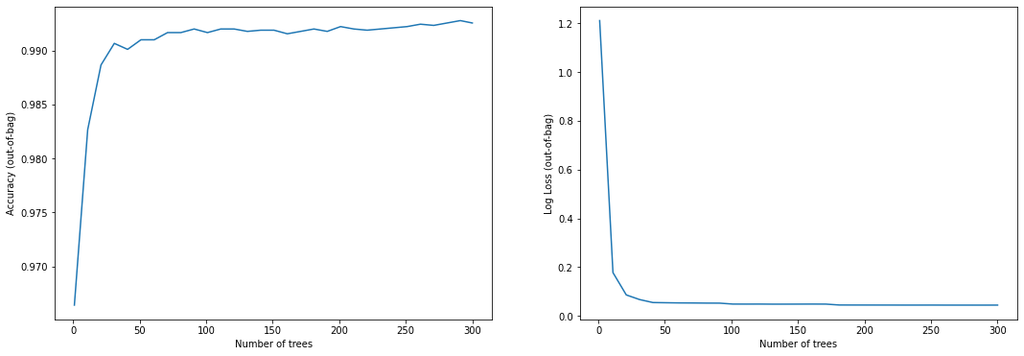

```python
logs = RF_model.make_inspector().training_logs()

plt.figure(figsize=(18, 6))
plt.subplot(1, 2, 1)
plt.plot([log.num_trees for log in logs], [log.evaluation.accuracy for log in logs])
plt.xlabel("Number of trees")
plt.ylabel("Accuracy (out-of-bag)")
plt.subplot(1, 2, 2)
plt.plot([log.num_trees for log in logs], [log.evaluation.loss for log in logs])
plt.xlabel("Number of trees")
plt.ylabel("Log Loss (out-of-bag)")
plt.show()
```

```python
RF_eval = RF_model.evaluate(tfds_train, return_dict=True)
print()

for name, value in RF_eval.items():
    print(f"{name}: {value:.4f}")
```

```
loss: 0.0000
accuracy: 0.9988
sparse_categorical_crossentropy: 0.0200
```

### 3.c) Train and Evaluate the Decision Trees Model

```python
# Define the baseline model for benchmarking
start_time_module = datetime.now()
tf.keras.utils.set_random_seed(RNG_SEED)
CART_model = tfdf.keras.CartModel(task = tfdf.keras.Task.CLASSIFICATION)
CART_model.compile(metrics=DEFAULT_METRICS)

# "sys_pipes" is optional. It enables the display of the training logs.
# with sys_pipes():
#     CART_model.fit(x=tfds_train)

# Train the model.
CART_model.fit(x=tfds_train)
print ('Model training time:', (datetime.now() - start_time_module), '\n')
```

```
Use /tmp/tmpgsfhjsbg as temporary training directory
Starting reading the dataset
Dataset read in 0:00:03.864395
Training model
Model trained in 0:00:00.256441
Compiling model
Model training time: 0:00:06.260207
```

```python
CART_eval = CART_model.evaluate(tfds_train, return_dict=True)
print()

for name, value in CART_eval.items():
    print(f"{name}: {value:.4f}")
```

```
loss: 0.0000
accuracy: 0.9761
sparse_categorical_crossentropy: 0.0524
```

### 3.d) Train and Evaluate the Gradient Boosted Trees Model

```python
# Define the baseline model for benchmarking
start_time_module = datetime.now()
tf.keras.utils.set_random_seed(RNG_SEED)
GBT_model = tfdf.keras.GradientBoostedTreesModel(task = tfdf.keras.Task.CLASSIFICATION)
GBT_model.compile(metrics=DEFAULT_METRICS)

# "sys_pipes" is optional. It enables the display of the training logs.
# with sys_pipes():
#     GBT_model.fit(x=tfds_train)

# Train the model.
GBT_model.fit(x=tfds_train)
print ('Model training time:', (datetime.now() - start_time_module), '\n')
```

```
Use /tmp/tmp2hl2wr4e as temporary training directory
Starting reading the dataset
Dataset read in 0:00:04.283923
Training model
Model trained in 0:03:02.578339
Compiling model
Model training time: 0:03:09.391541
```

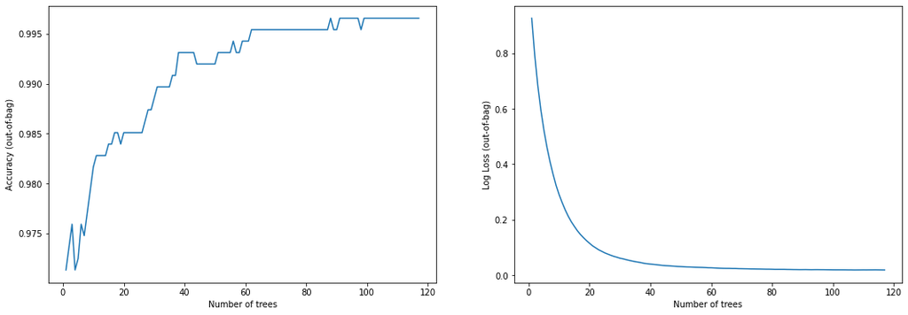

```python
logs = GBT_model.make_inspector().training_logs()

plt.figure(figsize=(18, 6))
plt.subplot(1, 2, 1)
plt.plot([log.num_trees for log in logs], [log.evaluation.accuracy for log in logs])
plt.xlabel("Number of trees")
plt.ylabel("Accuracy (out-of-bag)")
plt.subplot(1, 2, 2)
plt.plot([log.num_trees for log in logs], [log.evaluation.loss for log in logs])
plt.xlabel("Number of trees")
plt.ylabel("Log Loss (out-of-bag)")
plt.show()
```

```python
GBT_eval = GBT_model.evaluate(tfds_train, return_dict=True)
print()

for name, value in GBT_eval.items():
    print(f"{name}: {value:.4f}")
```

```
loss: 0.0000
accuracy: 0.9997
sparse_categorical_crossentropy: 0.0357
```

```python
if NOTIFY_STATUS: status_notify("Task 4 - Train and Evaluate Models completed! "+datetime.now().strftime('%a %B %d, %Y %I:%M:%S %p'))
```

## Task 4 - Fine-tune and Improve Models

```python
if NOTIFY_STATUS: status_notify("Task 4 - Fine-tune and Improve Models has begun! "+datetime.now().strftime('%a %B %d, %Y %I:%M:%S %p'))
```

```python
# Not applicable for this iteration of modeling
```

```python
if NOTIFY_STATUS: status_notify("Task 4 - Fine-tune and Improve Models completed! "+datetime.now().strftime('%a %B %d, %Y %I:%M:%S %p'))
```

## Task 5 - Finalize Model and Present Analysis

```python
if NOTIFY_STATUS: status_notify("Task 5 - Finalize Model and Present Analysis has begun! "+datetime.now().strftime('%a %B %d, %Y %I:%M:%S %p'))
```

### 5.a) Train the Final Model

```python
# Define the baseline model for benchmarking
start_time_module = datetime.now()
tf.keras.utils.set_random_seed(RNG_SEED)
# final_model = tfdf.keras.RandomForestModel(task = tfdf.keras.Task.CLASSIFICATION)
# final_model = tfdf.keras.CartModel(task = tfdf.keras.Task.CLASSIFICATION)
final_model = tfdf.keras.GradientBoostedTreesModel(task = tfdf.keras.Task.CLASSIFICATION)

# Optionally, add evaluation metrics.
final_model.compile(metrics=DEFAULT_METRICS)

# "sys_pipes" is optional. It enables the display of the training logs.
# with sys_pipes():
#     final_model.fit(x=tfds_train)

# Train the model.
final_model.fit(x=tfds_train)
print ('Model training time:', (datetime.now() - start_time_module), '\n')
```

```
Use /tmp/tmpi5_l5fw6 as temporary training directory
Starting reading the dataset
Dataset read in 0:00:04.085504
Training model
Model trained in 0:03:01.016228
Compiling model
Model training time: 0:03:26.603500
```

```python
final_model.summary()
```

```
Model: "gradient_boosted_trees_model_1"
_________________________________________________________________
 Layer (type)                Output Shape              Param #
=================================================================
=================================================================
Total params: 1
Trainable params: 0
Non-trainable params: 1
_________________________________________________________________
Type: "GRADIENT_BOOSTED_TREES"
Task: CLASSIFICATION
Label: "__LABEL"

Input Features (236):
	AREA
	COMPACTNESS
	ECCENTRICITY
	EQDIASQ
	EXTENT
	Gabor_B1
	Gabor_B2
	Gabor_B3
	Gabor_B4
	Gabor_B5
	Gabor_B6
	Gabor_B7
	Gabor_B8
	Gabor_B9
	Gabor_Cb1
	Gabor_Cb2
	Gabor_Cb3
	Gabor_Cb4
	Gabor_Cb5
	Gabor_Cb6
	Gabor_Cb7
	Gabor_Cb8
	Gabor_Cb9
	Gabor_Cr1
	Gabor_Cr2
	Gabor_Cr3
```

[output cut: 2064 more lines]

```
	1 : Gabor_X2(XYZ) [NUMERICAL]
	1 : Gabor_L6 [NUMERICAL]

Condition type in nodes:
	7407 : HigherCondition
Condition type in nodes with depth <= 0:
	321 : HigherCondition
Condition type in nodes with depth <= 1:
	962 : HigherCondition
Condition type in nodes with depth <= 2:
	2144 : HigherCondition
Condition type in nodes with depth <= 3:
	4170 : HigherCondition
Condition type in nodes with depth <= 5:
	7407 : HigherCondition
```

### 5.b) Load Test Dataset and Make Predictions

```python
# Finalize the test dataset for the prediction activities
tfds_test = tfdf.keras.pd_dataframe_to_tf_dataset(df_features_test, task = tfdf.keras.Task.CLASSIFICATION)
```

```python
# Finalize the test dataset for the testing activities
array_target_test = df_target_test.ravel()
print("Shape of df_target_test: {}".format(array_target_test.shape))
```

```
Shape of df_target_test: (900,)
```

```python
# Make batched predictions
# test_predictions = label_encoder.inverse_transform(np.argmax(final_model.predict(tfds_test), axis=-1))
test_predictions = np.argmax(final_model.predict(tfds_test), axis=-1)
print(test_predictions)
```

[output not shown]

[output not shown]

[output not shown]

```python
print('Accuracy Score:', accuracy_score(array_target_test, test_predictions))
print(confusion_matrix(array_target_test, test_predictions))
print(classification_report(array_target_test, test_predictions))
```

```
Accuracy Score: 0.9988888888888889
[[300   0   0]
 [  0 299   1]
 [  0   0 300]]
              precision    recall  f1-score   support

           0       1.00      1.00      1.00       300
           1       1.00      1.00      1.00       300
           2       1.00      1.00      1.00       300

    accuracy                           1.00       900
   macro avg       1.00      1.00      1.00       900
weighted avg       1.00      1.00      1.00       900
```

```python
if NOTIFY_STATUS: status_notify("Task 5 - Finalize Model and Present Analysis completed! "+datetime.now().strftime('%a %B %d, %Y %I:%M:%S %p'))
```

```python
print ('Total time for the script:',(datetime.now() - start_time_script))
```

```
Total time for the script: 0:09:53.411209
```